# Hierarchical Models with the rstanarm and brms Packages

May 04, 2020

## Final Projects

- Due by 11:59 PM on May 19th
- Can analyze data used in another class
- If you cannot share the data, let me know
- Can use rstanarm or brms or write your own Stan code (next week)
- I don’t care very much what the previous literature says
- Go through the process of laying out a generative model, drawing from the prior predictive distribution, conditioning on the observed data (and making sure Stan samples well), looking at posterior predictive plots, comparing it to an alternative model, etc.
- Should be around ten pages as a PDF

## `GLD_solver_LBFGS` in GLD_helpers.R

- Week2/GLD_helpers.R now has a `GLD_solver_LBFGS` function

```r
source(file.path("..", "Week2", "GLD_helpers.R"))
args(GLD_solver_LBFGS)
```

```
## function (lower_quartile, median, upper_quartile, other_quantile,
##     alpha, check = TRUE)
## NULL
```

are the same as `GLD_solver`

- The `GLD_solver_LBFGS` function throws warnings rather than errors when it cannot find an exact solution for the asymmetry and steepness parameters

```r
rstan::expose_stan_functions(file.path("..", "Week2", "quantile_functions.stan"))
a_s <- GLD_solver_LBFGS(lower_quartile = 3, median = 5, upper_quartile = 8,
                        other_quantile = 1200, alpha = 0.9) # warnings
```

```
## Warning in GLD_solver_LBFGS(lower_quartile = 3, median = 5, upper_quartile = 8, : ERROR: ABNORMAL_TERMINATION_IN_LNSRCH
## no GLD is exactly possible with these quantiles, so check that the results are decent
```

## What Are Hierarchical Models

- In Bayesian terms, a hierarchical model is nothing more than a model where the prior distribution of some parameter depends on another parameter
- In other words, it is just another application of the Multiplication Rule \[f\left(\boldsymbol{\theta}\right) = \int f\left(\boldsymbol{\theta} \mid \boldsymbol{\phi}\right) f\left(\boldsymbol{\phi}\right) d\phi_1 \dots d\phi_K\]
- But most of the discussion of “hierarchical models” refers to the very narrow circumstances in which they can be estimated via frequentist methods
- From a frequentist perspective, a hierarchical model is appropriate for cluster random sampling designs, inappropriate for stratified random sample designs, and hard to justify for other sampling designs

## Breakout Rooms

Suppose the coefficient on age is a linear function of the income of the person’s zip code in a logit model for whether they vote, in the Oregon Medicaid experiment dataset from the homework. Draw from the prior predictive distribution in R using `replicate`. You can ignore the other predictors.

## Cluster Sampling vs. Stratified Sampling

- For cluster random sampling, you
  - Sample \(J\) large units (such as schools) from their population
  - Sample \(N_j\) small units (such as students) from the \(j\)-th large unit
- If you replicate such a study, you get different realizations of the large units
- For stratified random sampling, you
  - Divide the population of large units into \(J\) mutually exclusive and exhaustive groups (like states)
  - Sample \(N_j\) small units (such as voters) from the \(j\)-th large unit
- If you replicate such a study, you would use the same large units and only get different realizations of the small units

## Why Bayesians Should Use Hierarchical Models

- Suppose you estimated a Bayesian model on people in New York
- Next, you are going to collect data on people who live in Connecticut
- Intuitively, the New York posterior should influence the Connecticut prior
- But it is unlikely that the data-generating processes in Connecticut is exactly the same as in New York
- Hierarchical models apply when you have data from New York, Connecticut, and other states at the same time
- Posterior distribution in any one state is not independent of other states
- Posterior distribution in any one state are not the same as in other states
- McElreath argues hierarchical models should be the default and “flat” models should be the rare exception only when justified by the data
- With more data, there is always more heterogeneity in the data-generating processes that a generative model should be allowing for

## Models with Group-Specific Intercepts

- Let \(\alpha\) be the common intercept and \(\boldsymbol{\beta}\) be the common coefficients while \(a_j\) is the deviation from the common intercept in the \(j\)-th group. Write a model as: \[y_{ij} = \overbrace{\underbrace{\alpha + \sum_{k = 1}^K \beta_k x_{ik}}_{\mbox{Frequentist } \boldsymbol{\mu} \mid \mathbf{x}}+a_j}^{\mbox{Bayesian } \boldsymbol{\mu} \mid \mathbf{x},j} +\boldsymbol{\epsilon} = \alpha + \sum_{k = 1}^K \beta_k x_{ik}+\underbrace{a_j + \overbrace{\boldsymbol{\epsilon}}^{\mbox{Bayesian error}}}_{\mbox{Frequentist error}}\]
- The same holds in GLMs where \(\eta_{ij} = \alpha + \sum_{k = 1}^K \beta_k x_{ik} + a_j\) or \(\eta_{ij} = \alpha + \sum_{k = 1}^K \beta_k x_{ik}\) depending on whether you are Bayesian or Frequentist

## Models with Group-Specific Slopes and Intercepts

- Let \(\alpha\) be the common intercept and \(\boldsymbol{\beta}\) be the common coefficients while \(a_j\) is the deviation from the common intercept in the \(j\)-th group and \(\mathbf{b}_j\) is the deviation from the common coefficients. Write the model as: \[y_{ij} = \overbrace{\underbrace{\alpha + \sum_{k = 1}^K \beta_k x_{ik}}_{\mbox{Frequentist } \boldsymbol{\mu} \mid \mathbf{x}} + a_j + \sum_{k = 1}^K b_{jk} x_{ik}}^{\mbox{Bayesian } \boldsymbol{\mu} \mid \mathbf{x},j} +\boldsymbol{\epsilon} = \\ \alpha + \sum_{k = 1}^K \beta_k x_{ik}+\underbrace{a_j + \sum_{k = 1}^K b_{jk} x_{ik} + \overbrace{\boldsymbol{\epsilon}}^{\mbox{Bayesian error}}}_{\mbox{Frequentist error}}\]
- And similarly for GLMs

## Frequentist Estimation of Multilevel Models

- Frequentists assume that \(a_j\) and \(b_j\) deviate from the common parameters according to a (multivariate) normal distribution, whose (co)variances are common parameters to be estimated
- To Frequentists, \(a_j\) and \(b_j\) are not parameters because parameters must remained fixed in repeated sampling of observations from some population
- Since \(a_j\) and \(b_j\) are not parameters, they can’t be “estimated” only “predicted”
- Since \(a_j\) and \(b_j\) aren’t estimated, they must be integrated out of the likelihood function, leaving an integrated likelihood function of the common parameters
- After obtaining maximum likelihood estimates of the common parameters, each \(a_j\) and \(b_j\) can be predicted from the residuals via a regression
- Estimated standard errors produced by frequentist software are too small
- There are no standard errors etc. for the \(a_j\) and \(b_j\)
- Maximum likelihood estimation often results in a corner solution

## Table 2 from the **lme4** [Vignette](https://www.jstatsoft.org/article/view/v067i01/0) (see also the [FAQ](https://bbolker.github.io/mixedmodels-misc/glmmFAQ.html#model-specification))

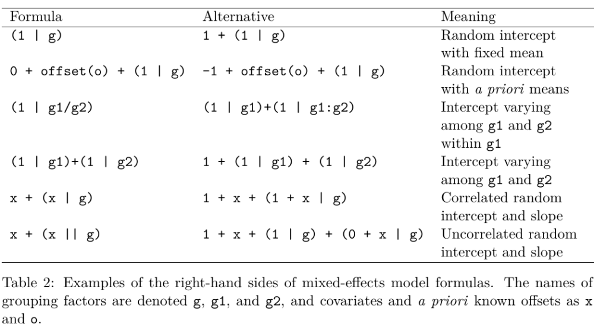

lme4 syntax

## Hierarchical Models in Psychology

- In political science and economics, the “big” units are often countries or sub-national political areas like states and the “small” units are people
- In [psychology](https://arxiv.org/pdf/1506.04967.pdf), the “big” units are often people and the “small” units are questions or outcomes on repeated tasks
- Hierarchical model syntax is like

```r
y ~ x + (x | person) + (1 | question)
```

- Question of interest is how to predict `y` for a new “big” unit (person)

## Hierarchical Models in **rstanarm** (from this [paper](http://www.tqmp.org/RegularArticles/vol14-2/p099/p099.pdf))

```r
dat <- read.csv("https://osf.io/5cg32/download")
library(rstanarm)
```

```r
post <-  stan_glmer(valence ~ arousal + (1 + arousal | PID), data = dat,
                    prior = normal(0, 1, autoscale = FALSE),
                    prior_intercept = normal(50, 100, autoscale = FALSE))
```

```r
post
```

```
...
##             Median MAD_SD
## (Intercept) 29.9    5.4
## arousal      0.5    0.1
##
## Auxiliary parameter(s):
##       Median MAD_SD
## sigma 9.3    0.4
##
## Error terms:
##  Groups   Name        Std.Dev. Corr
##  PID      (Intercept) 20.71
##           arousal      0.24    -0.66
##  Residual              9.27
## Num. levels: PID 20
##
...
```

## Accessor Functions (based on the **lme4** package)

```r
fixef(post)
```

```
## (Intercept)     arousal
##  29.9281178   0.5380694
```

```r
cbind(b = head(ranef(post)$PID), total = head(coef(post)$PID))
```

```
##   b.(Intercept)   b.arousal total.(Intercept) total.arousal
## 1     36.987540 -0.16446363          66.91566     0.3736058
## 2     17.187123 -0.08308324          47.11524     0.4549861
## 3     38.584861 -0.20028856          68.51298     0.3377808
## 4      9.849710 -0.10118385          39.77783     0.4368855
## 5    -13.972518  0.02890319          15.95560     0.5669726
## 6      1.199908 -0.06238785          31.12803     0.4756815
```

```r
dim(as.matrix(post)) # 4000 x 46
```

```
## [1] 4000   46
```

## Posterior Predictive Checks

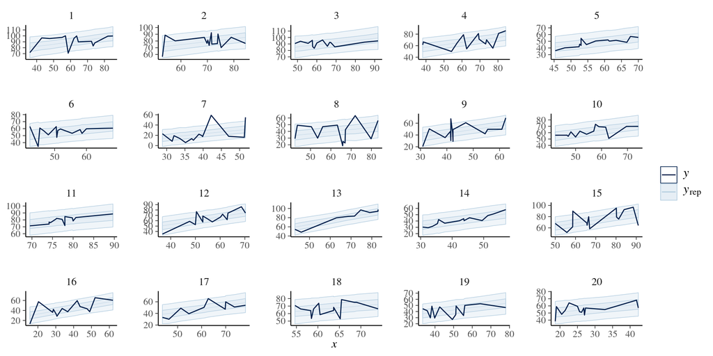

```r
pp_check(post, plotfun = "ribbon_grouped", x = dat$arousal, group = dat$PID)
```

## Frequentist Example

```r
poll <- readRDS("GooglePoll.rds") # WantToWin is coded as 1 for Romney and 0 for Obama
poll$Income[poll$Income == "150,000+"] <- "100,000-149,999"
library(dplyr)
collapsed <- filter(poll, !is.na(WantToWin)) %>%
             group_by(Region, Gender, Urban_Density, Age, Income) %>%
             summarize(Romney = sum(grepl("Romney", WantToWin)), Obama = n() - Romney) %>%
             na.omit
```

```r
lme4::glmer(cbind(Romney, Obama) ~ Gender + Urban_Density + Age + Income +
              (Gender + Urban_Density + Age + Income | Region),
            data = collapsed, family = binomial(link = "logit"))
```

```
## singular fit
```

- For models that are more complicated than `(1 + x | g)`, the MLE of \(\boldsymbol{\Sigma}\) usually implies that \(\widehat{\boldsymbol{\Sigma}}^{-1}\) does not exist

## Bayesian Version of the “Same” Model

```r
post_h <- stan_glmer(cbind(Romney, Obama) ~ Gender + Urban_Density + Age + Income +
                       (Gender + Urban_Density + Age + Income | Region),
                     data = collapsed, family = binomial(link = "logit"),
                     QR = TRUE, adapt_delta = 0.98, seed = 12345)
```

```r
post_h
```

```
...
##  observations: 513
## ------
##                       Median MAD_SD
## (Intercept)           -0.5    0.2
## GenderMale             0.4    0.1
## Urban_DensitySuburban -0.2    0.1
## Urban_DensityUrban    -0.5    0.1
## Age25-34               0.1    0.1
## Age35-44               0.5    0.1
## Age45-54               0.8    0.1
## Age55-64               0.8    0.1
## Age65+                 1.3    0.1
## Income25,000-49,999   -0.1    0.1
## Income50,000-74,999   -0.1    0.1
## Income75,000-99,999   -0.1    0.2
## Income100,000-149,999  0.2    0.3
##
## Error terms:
##  Groups Name                  Std.Dev. Corr
##  Region (Intercept)           0.169
##         GenderMale            0.093     0.00
##         Urban_DensitySuburban 0.096    -0.02  0.00
##         Urban_DensityUrban    0.098     0.02  0.00  0.07
##         Age25-34              0.107     0.07 -0.01  0.00  0.02
##         Age35-44              0.122     0.00  0.02  0.02  0.01  0.01
##         Age45-54              0.113     0.09 -0.02  0.00  0.02  0.06 -0.04
##         Age55-64              0.100     0.02  0.00  0.01  0.01  0.02  0.00  0.04
##         Age65+                0.108     0.03 -0.01 -0.01  0.01  0.02 -0.03  0.04  0.04
##         Income25,000-49,999   0.115    -0.08 -0.02 -0.03 -0.01 -0.02 -0.08  0.00  0.00
##         Income50,000-74,999   0.115    -0.03 -0.01  0.01 -0.01 -0.01  0.01 -0.01 -0.01
##         Income75,000-99,999   0.129    -0.03  0.03 -0.01 -0.01 -0.02  0.03 -0.05 -0.03
##         Income100,000-149,999 0.130     0.03 -0.01  0.01  0.01  0.01  0.01  0.02  0.01
##
##
##
##
##
##
##
##
##
##
##   0.03
##   0.00  0.02
##  -0.03  0.00 -0.01
##   0.01 -0.01  0.00 -0.02
## Num. levels: Region 4
##
## Sample avg. posterior predictive distribution of y:
##          Median MAD_SD
## mean_PPD 5.5    0.1
##
## ------
## * For help interpreting the printed output see ?print.stanreg
## * For info on the priors used see ?prior_summary.stanreg
...
```

## Poststratification

```r
mu <- posterior_linpred(post_h, transform = TRUE)
dim(mu)
```

```
## [1] 4000  513
```

- Assume `shares` is the proportion of voters for each level of `Gender`, `Urban_Density`, `Age`, and `Income` crossed with `Region`

```r
mu_ <- mu %*% shares
```

- Now you have a posterior distribution for the proportion supporting Romney for the country as a whole

## PSISLOOCV (of a group)

```r
(loo_hier <- loo(post_h)) # 156 parameters
```

```
...
##          Estimate   SE
## elpd_loo   -845.9 20.5
## p_loo        27.6  2.3
## looic      1691.8 41.1
## ------
## Monte Carlo SE of elpd_loo is 0.1.
##
## All Pareto k estimates are good (k < 0.5).
## See help('pareto-k-diagnostic') for details.
NA
NA
NA
NA
...
```

## What Were the Priors?

```r
prior_summary(post_h)
```

```
## Priors for model 'post_h'
## ------
## Intercept (after predictors centered)
##  ~ normal(location = 0, scale = 10)
##
## Coefficients (in Q-space)
##  ~ normal(location = [0,0,0,...], scale = [2.5,2.5,2.5,...])
##
## Covariance
##  ~ decov(reg. = 1, conc. = 1, shape = 1, scale = 1)
## ------
## See help('prior_summary.stanreg') for more details
```

## What Is `decov(1, 1, 1, 1)`?

- `decov` = Decomposition of Covariance
- `reg.` is the regularization parameter in the LKJ prior on the correlation matrix
- `conc.` is the concentration parameter in the Dirichlet prior on the variance components
- `shape` and `scale` pertain to the Gamma prior on multiplier for the variance components
- You usually do not need to change these defaults to get good results

## Cafes Example from McElreath

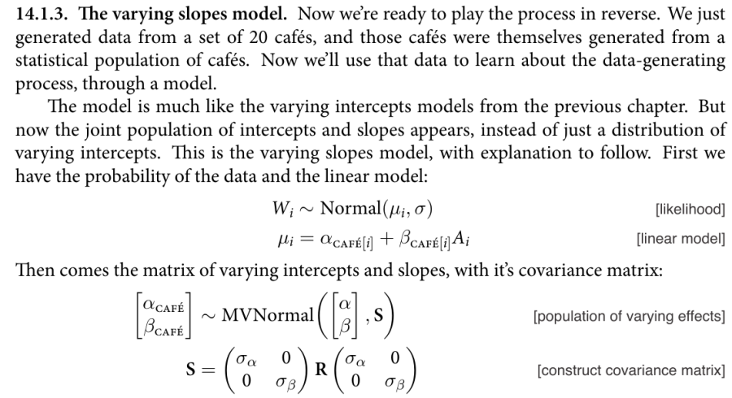

McElreath (2020) chapter 14

## Cafes Example with brms

```r
brm(wait ~ 1 + afternoon + (1 + afternoon | cafe), data = dataset,
    prior = c(prior(normal(0, 10), class = Intercept),
              prior(normal(0, 10), class = b),
              prior(cauchy(0, 2), class = sd),    # absolute value of Cauchy
              prior(cauchy(0, 2), class = sigma), # same
              prior(lkj(2), class = cor))         # just a correlation
```

- A Stan function to draw from the prior predictive distribution of this model is on the next slide

```stan
functions {
  matrix prior_PD_rng(int S, vector A, int[] cafe) {
    int N = rows(A); int J = max(cafe);
    int N_j = N / J; // assume all cafes have the same N_j
    vector[2] zeros = rep_vector(0, 2); matrix[S, N] draws;
    for (s in 1:S) {
      int pos = 1;
      real alpha = normal_rng(0, 10);
      real beta = normal_rng(0, 10);
      vector[N_j] sigma = rep_vector(fabs(cauchy_rng(0, 2)), N_j);
      real sigma_alpha = fabs(cauchy_rng(0, 2));
      real sigma_beta = fabs(cauchy_rng(0, 2));
      real rho = uniform_rng(-1, 1);
      matrix[2, 2] Sigma;
      Sigma[1, 1] = square(sigma_alpha);
      Sigma[1, 2] = sigma_alpha * sigma_beta * rho;
      Sigma[2, 1] = Sigma[1, 2];
      Sigma[2, 2] = square(sigma_beta);
      for (j in 1:J) {
        vector[2] a_b = multi_normal_rng(zeros, Sigma);
        vector[N_j] mu = alpha + a_b[1]
                       + (beta + a_b[2]) * A[pos:(pos + N_j - 1)];
        row_vector[N_j] epsilon = to_row_vector(normal_rng(0, sigma));
        draws[s, pos:(pos + N_j - 1)] = mu' + epsilon;
        pos += N_j;
      }
    }
    return draws;
  }
}
```

## McElreath / Kotz [Example](http://www.pnas.org/content/112/40/12349.abstract)

```r
library(brms)
funding <-
  tibble(
    discipline   = rep(c("Chemical sciences", "Physical sciences", "Physics", "Humanities",
                         "Technical sciences",  "Interdisciplinary", "Earth/life sciences",
                         "Social sciences", "Medical sciences"),
                     each = 2),
    gender       = rep(c("m", "f"), times = 9),
    applications = c(83, 39, 135, 39, 67, 9, 230, 166, 189, 62, 105, 78, 156, 126, 425, 409, 245, 260) %>% as.integer(),
    awards       = c(22, 10, 26, 9, 18, 2, 33, 32, 30, 13, 12, 17, 38, 18, 65, 47, 46, 29) %>% as.integer(),
    rejects      = c(61, 29, 109, 30, 49, 7, 197, 134, 159, 49, 93, 61, 118, 108, 360, 362, 199, 231) %>% as.integer(),
    male         = ifelse(gender == "f", 0, 1) %>% as.integer()
  )
```

```r
b13.bonus_2 <-
  brm(awards | trials(applications) ~ 1 + male + (1 + male | discipline),
      data = funding, family = binomial, control = list(adapt_delta = 0.9),
      prior = c(prior(normal(0, 4), class = Intercept), prior(normal(0, 4), class = b),
                prior(cauchy(0, 1), class = sd), prior(lkj(4), class = cor)))
```

## Results

```r
b13.bonus_2
```

```
##  Family: binomial
##   Links: mu = logit
## Formula: awards | trials(applications) ~ 1 + male + (1 + male | discipline)
##    Data: funding (Number of observations: 18)
## Samples: 4 chains, each with iter = 2000; warmup = 1000; thin = 1;
##          total post-warmup samples = 4000
##
## Group-Level Effects:
## ~discipline (Number of levels: 9)
##                     Estimate Est.Error l-95% CI u-95% CI Rhat Bulk_ESS Tail_ESS
## sd(Intercept)           0.27      0.14     0.03     0.60 1.00      895      555
## sd(male)                0.32      0.18     0.03     0.74 1.00     1014     1249
## cor(Intercept,male)    -0.17      0.31    -0.70     0.45 1.00     2957     3083
##
## Population-Level Effects:
##           Estimate Est.Error l-95% CI u-95% CI Rhat Bulk_ESS Tail_ESS
## Intercept    -1.62      0.15    -1.88    -1.31 1.00     1887     2062
## male          0.15      0.17    -0.21     0.48 1.00     2063     1987
##
## Samples were drawn using sampling(NUTS). For each parameter, Bulk_ESS
## and Tail_ESS are effective sample size measures, and Rhat is the potential
## scale reduction factor on split chains (at convergence, Rhat = 1).
```